# `symbox`: Boxplots for transformations to symmetry

#### Description

symbox first transforms x to each of a series of selected powers, with each transformation standardized to mean 0 and standard deviation 1. The results are then displayed side-by-side in boxplots, permiting a visual assessment of which power makes the distribution reasonably symmetric.

#### Usage

```
symbox(x, ...)
## S3 method for class 'formula'
symbox(formula, data=NULL, subset, na.action=NULL, ylab, ...)
## Default S3 method:
symbox(x, powers = c(-1, -0.5, 0, 0.5, 1), start,
trans=bcPower, xlab="Powers", ylab, ...)
```

#### Arguments

x a numeric vector. formula a one-sided formula specifying a single numeric variable. data, subset, na.action as for statistical modeling functions (see, e.g., lm). xlab, ylab axis labels; if ylab is missing, a label will be supplied. powers a vector of selected powers to which x is to be raised. For meaningful comparison of powers, 1 should be included in the vector of powers. start a constant to be added to x. If start is missing and trans is bcPower (the default) or bcnPower, then a start will be automatically generated if there are zero or negative values in x, and a warning will be printed; the auto-generated start is the absolute value of the minimum x plus 1 percent of the range of x. trans a transformation function whose first argument is a numeric vector and whose second argument is a transformation parameter, given by the powers argument; the default is bcPower, and another possibility is yjPower. bcnPower may also be used, in which case the gamma parameter is set to the value of start. … arguments to be passed down.

#### Examples

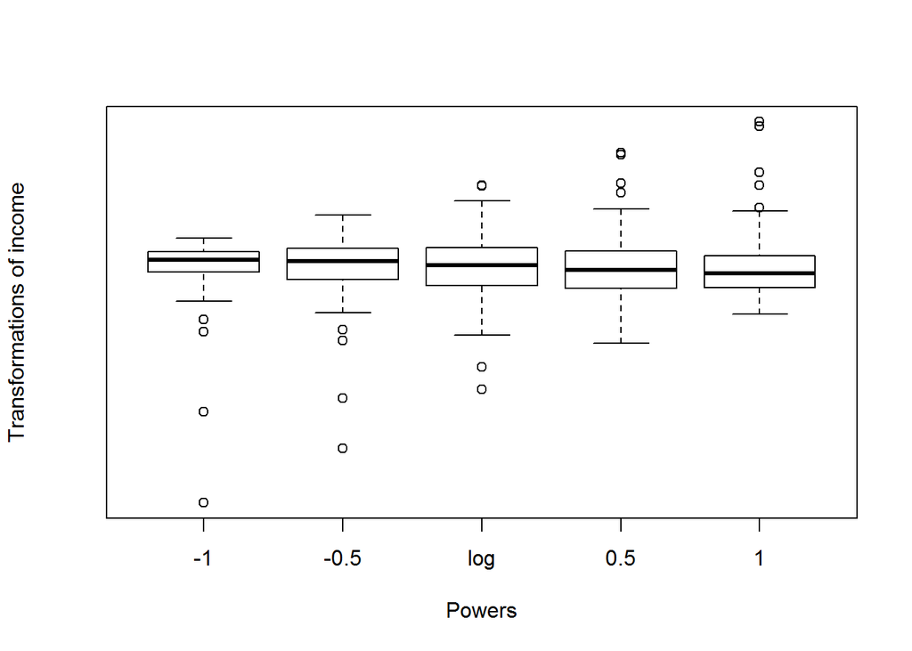

```r
symbox(~ income, data=Prestige)
```

#### References

Fox, J. and Weisberg, S. (2019) An R Companion to Applied Regression, Third Edition. Sage. See Also boxplot, boxcox, bcPower, yjPower